# Supplementary code to Tight gene co-expression between oocyte and surrounding cumulus is critical for oocyte developmental competence

### Analysis of blastocys yield

```r
.libPaths("/usr/lib/R/site-library")

library("tidyverse", quietly = TRUE, lib.loc="/usr/lib/R/site-library")
library("multcomp", quietly = TRUE, lib.loc="/usr/lib/R/site-library")
library("aod", quietly = TRUE, lib.loc="/usr/lib/R/site-library")
library("car", quietly = TRUE, lib.loc="/usr/lib/R/site-library")
library("emmeans", quietly = TRUE, lib.loc="/usr/lib/R/site-library")
library("lmtest", quietly = TRUE, lib.loc="/usr/lib/R/site-library")
```

Import the data of blastocyst development.

```r
Input = ("
Replicate   Group   B   NB
1 BCB+ 11 59
1   BCB- 12 79
2   BCB+ 7  28
2   BCB-    3   18
2   C   10 65
3   BCB+ 16 49
3   BCB- 16 136
3   C 10 36
4 BCB+ 20 112
4 BCB- 6 125
")

Data = read.table(textConnection(Input),header=TRUE)
Data$Replicate<-as.factor(Data$Replicate)
Data$Group<-as.factor(Data$Group)
```

#### Blastocyst yield from COCs separated based on BCB staining

##### Table 1

Logistic regression to test the effect of BCB staining on blastocyst yield, followed by the Wald test of significance.

```r
model.log<-glm(cbind(B,NB) ~ Group + Replicate, family = binomial(link = "logit"), data = Data)
Anova(model.log,     type="III",      test.statistic="Wald")
```

```
## Analysis of Deviance Table (Type III tests)
##
## Response: cbind(B, NB)
##             Df   Chisq Pr(>Chisq)
## (Intercept)  1 69.8847  < 2.2e-16 ***
## Group        2 12.9639   0.001531 **
## Replicate    3  6.2416   0.100430
## ---
## Signif. codes:  0 '***' 0.001 '**' 0.01 '*' 0.05 '.' 0.1 ' ' 1
```

Likelyhood test of the effect of BCB staining on blastocyst yield.

```r
full.model.log<-glm(cbind(B,NB) ~  Replicate + Group, family = binomial(link = "logit"), data = Data)
reduced.model.log<-glm(cbind(B,NB) ~  Replicate, family = binomial(link = "logit"), data = Data)
lrtest(full.model.log,reduced.model.log)
```

```
## Likelihood ratio test
##
## Model 1: cbind(B, NB) ~ Replicate + Group
## Model 2: cbind(B, NB) ~ Replicate
##   #Df  LogLik Df  Chisq Pr(>Chisq)
## 1   6 -22.015
## 2   4 -28.711 -2 13.394   0.001235 **
## ---
## Signif. codes:  0 '***' 0.001 '**' 0.01 '*' 0.05 '.' 0.1 ' ' 1
```

##### Table 2

Tukey test for multiple comparison of means, and the odds ratio.

```r
summary(glht(model.log, linfct = mcp(Group = "Tukey")))
```

```
##
##   Simultaneous Tests for General Linear Hypotheses
##
## Multiple Comparisons of Means: Tukey Contrasts
##
##
## Fit: glm(formula = cbind(B, NB) ~ Group + Replicate, family = binomial(link = "logit"),
##     data = Data)
##
## Linear Hypotheses:
##                  Estimate Std. Error z value Pr(>|z|)
## BCB+ - BCB- == 0   0.8432     0.2347   3.593  0.00083 ***
## C - BCB- == 0      0.5530     0.3471   1.593  0.24347
## C - BCB+ == 0     -0.2903     0.3365  -0.863  0.65921
## ---
## Signif. codes:  0 '***' 0.001 '**' 0.01 '*' 0.05 '.' 0.1 ' ' 1
## (Adjusted p values reported -- single-step method)
```

```r
emmeans(model.log, ~Group, type='response') %>% multcomp::cld(Letters=letters)
```

```
##  Group   prob     SE  df asymp.LCL asymp.UCL .group
##  BCB-  0.0908 0.0153 Inf    0.0649     0.126  a
##  C     0.1479 0.0353 Inf    0.0911     0.231  ab
##  BCB+  0.1883 0.0240 Inf    0.1457     0.240   b
##
## Results are averaged over the levels of: Replicate
## Confidence level used: 0.95
## Intervals are back-transformed from the logit scale
## P value adjustment: tukey method for comparing a family of 3 estimates
## Tests are performed on the log odds ratio scale
## significance level used: alpha = 0.05
## NOTE: Compact letter displays can be misleading
##       because they show NON-findings rather than findings.
##       Consider using 'pairs()', 'pwpp()', or 'pwpm()' instead.
```

```r
emmeans(model.log, pairwise ~ Group, type='response')
```

```
## $emmeans
##  Group   prob     SE  df asymp.LCL asymp.UCL
##  BCB-  0.0908 0.0153 Inf    0.0649     0.126
##  BCB+  0.1883 0.0240 Inf    0.1457     0.240
##  C     0.1479 0.0353 Inf    0.0911     0.231
##
## Results are averaged over the levels of: Replicate
## Confidence level used: 0.95
## Intervals are back-transformed from the logit scale
##
## $contrasts
##  contrast        odds.ratio    SE  df null z.ratio p.value
##  (BCB-) / (BCB+)      0.430 0.101 Inf    1  -3.593  0.0010
##  (BCB-) / C           0.575 0.200 Inf    1  -1.593  0.2485
##  (BCB+) / C           1.337 0.450 Inf    1   0.863  0.6640
##
## Results are averaged over the levels of: Replicate
## P value adjustment: tukey method for comparing a family of 3 estimates
## Tests are performed on the log odds ratio scale
```

### Analysis of mtDNA copy

#### Mitochondrial DNA abundance in single oocytes classified by BCB staining

Analyze the mtDNA data produced by real-time quantitative polymerase chain reaction.

```r
mtDNA_data$Plate<-as.factor(mtDNA_data$Plate)
mtDNA_data$Group<-as.factor(mtDNA_data$Group)
```

##### Supplemental table 1

Analyze the variance of the mtDNA counts obtained by real-time quantitative polymerase chain reaction.

```r
mtDNAmodel<-lm(Copy_number ~   Plate + Group ,contrasts=list(Plate='contr.sum', Group ='contr.sum'), data = mtDNA_data)
summary(mtDNAmodel)
```

```
##
## Call:
## lm(formula = Copy_number ~ Plate + Group, data = mtDNA_data,
##     contrasts = list(Plate = "contr.sum", Group = "contr.sum"))
##
## Residuals:
##      Min       1Q   Median       3Q      Max
## -1602259  -520845   -79130   321959  2168324
##
## Coefficients:
##             Estimate Std. Error t value Pr(>|t|)
## (Intercept)  1699487      85792  19.809  < 2e-16 ***
## Plate1       -201216     122398  -1.644  0.10401
## Plate2        -31977     120206  -0.266  0.79089
## Group1        258963      88428   2.929  0.00441 **
## ---
## Signif. codes:  0 '***' 0.001 '**' 0.01 '*' 0.05 '.' 0.1 ' ' 1
##
## Residual standard error: 793500 on 82 degrees of freedom
## Multiple R-squared:  0.1123, Adjusted R-squared:  0.0798
## F-statistic: 3.457 on 3 and 82 DF,  p-value: 0.02012
```

```r
car::Anova(mtDNAmodel,type='III')
```

```
## Anova Table (Type III tests)
##
## Response: Copy_number
##                 Sum Sq Df  F value    Pr(>F)
## (Intercept) 2.4708e+14  1 392.4159 < 2.2e-16 ***
## Plate       2.5142e+12  2   1.9965  0.142352
## Group       5.4000e+12  1   8.5763  0.004408 **
## Residuals   5.1631e+13 82
## ---
## Signif. codes:  0 '***' 0.001 '**' 0.01 '*' 0.05 '.' 0.1 ' ' 1
```

##### Supplemental table 2

Post hoc Tukey test for comparison of means.

```r
summary(glht(mtDNAmodel, linfct = mcp(Group = "Tukey")))
```

```
##
##   Simultaneous Tests for General Linear Hypotheses
##
## Multiple Comparisons of Means: Tukey Contrasts
##
##
## Fit: lm(formula = Copy_number ~ Plate + Group, data = mtDNA_data,
##     contrasts = list(Plate = "contr.sum", Group = "contr.sum"))
##
## Linear Hypotheses:
##                          Estimate Std. Error t value Pr(>|t|)
## Positive - Negative == 0  -517926     176855  -2.929  0.00441 **
## ---
## Signif. codes:  0 '***' 0.001 '**' 0.01 '*' 0.05 '.' 0.1 ' ' 1
## (Adjusted p values reported -- single-step method)
```

```r
emmeans(mtDNAmodel, pairwise ~ Group, type='response')
```

```
## $emmeans
##  Group     emmean     SE df lower.CL upper.CL
##  Negative 1958450 126717 82  1706370  2210529
##  Positive 1440524 119592 82  1202618  1678429
##
## Results are averaged over the levels of: Plate
## Confidence level used: 0.95
##
## $contrasts
##  contrast            estimate     SE df t.ratio p.value
##  Negative - Positive   517926 176855 82   2.929  0.0044
##
## Results are averaged over the levels of: Plate
```

```r
emmeans(mtDNAmodel, ~Group, type='response') %>% multcomp::cld(Letters=letters)
```

```
##  Group     emmean     SE df lower.CL upper.CL .group
##  Positive 1440524 119592 82  1202618  1678429  a
##  Negative 1958450 126717 82  1706370  2210529   b
##
## Results are averaged over the levels of: Plate
## Confidence level used: 0.95
## significance level used: alpha = 0.05
## NOTE: Compact letter displays can be misleading
##       because they show NON-findings rather than findings.
##       Consider using 'pairs()', 'pwpp()', or 'pwpm()' instead.
```

##### Supplemental figure 1

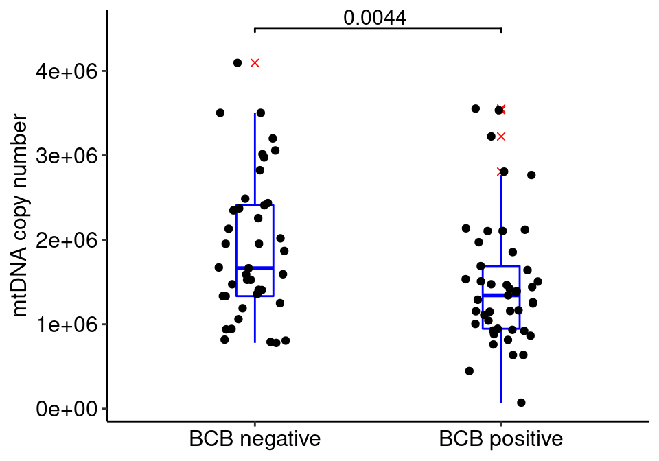

```r
ggplot(data=mtDNA_data, aes(x=Group, y=Copy_number))+
  geom_boxplot(color="blue",width=0.15, outlier.color = "red",outlier.shape = 4,outlier.size = 1.5)+
  geom_jitter( width=0.15)+
  scale_y_continuous(name="mtDNA copy number")+
  scale_x_discrete(name=NULL,labels=c("Negative"="BCB negative", "Positive"="BCB positive"))+
  ggsignif::geom_signif(annotations = c("0.0044 "), y_position=4500000, xmin = c(1),xmax=c(2),tip_length = 0.01, textsize=4)+
  theme_classic()+
  theme(
    axis.title = element_text(size=12, color="black"),
    axis.text = element_text(size=12, color="black")
  )
```

Supplemental figure 1. Mitochondrial DNA copy number quantified in single oocytes classified by brilliant cresyl blue staining.

### Analysis RNA-seq data

```r
.libPaths("/usr/lib/R/site-library")
library("edgeR", quietly = TRUE, lib.loc="/usr/lib/R/site-library")
library("DESeq2", quietly = TRUE, lib.loc="/usr/lib/R/site-library")
library("DEsingle", quietly = TRUE, lib.loc="/usr/lib/R/site-library")
library("biomaRt",quietly = TRUE, lib.loc="/usr/lib/R/site-library")
library("goseq" ,quietly = TRUE, lib.loc="/usr/lib/R/site-library")
library("VennDiagram", quietly = TRUE, lib.loc="/usr/lib/R/site-library")
library("ggpubr", quietly = TRUE, lib.loc="/usr/lib/R/site-library")
library("Rtsne", quietly = TRUE,lib.loc="/usr/lib/R/site-library")
library("MEGENA",quietly = TRUE, lib.loc="/usr/lib/R/site-library")
library("DGCA", quietly = TRUE, lib.loc="/usr/lib/R/site-library")
library('dplyr', quietly = TRUE,lib.loc="/usr/lib/R/site-library")
library("ggplot2", quietly = TRUE, lib.loc="/usr/lib/R/site-library")
library("ggrepel", quietly = TRUE, lib.loc="/usr/lib/R/site-library")
library("gridExtra",quietly = TRUE , lib.loc="/usr/lib/R/site-library")
library("readr" , quietly = TRUE, lib.loc="/usr/lib/R/site-library")
library("ggfortify" , quietly = TRUE, lib.loc="/usr/lib/R/site-library")
library("cowplot" , quietly = TRUE, lib.loc="/usr/lib/R/site-library")
library("tidyverse", quietly = TRUE, lib.loc="/usr/lib/R/site-library")
library("WGCNA", quietly = TRUE, lib.loc="/usr/lib/R/site-library")
library("reshape2", quietly = TRUE, lib.loc="/usr/lib/R/site-library")
library("foreach", quietly = TRUE, lib.loc="/usr/lib/R/site-library")
library("doParallel", quietly = TRUE, lib.loc="/usr/lib/R/site-library")
library("bigmemory", quietly = TRUE, lib.loc="/usr/lib/R/site-library")
library("gtools", quietly = TRUE, lib.loc="/usr/lib/R/site-library")
library("data.table", quietly = TRUE, lib.loc="/usr/lib/R/site-library")
library("flashClust", quietly = TRUE, lib.loc="/usr/lib/R/site-library")
library("dendextend", quietly = TRUE, lib.loc="/usr/lib/R/site-library")
library('vegan', quietly = TRUE, lib.loc="/usr/lib/R/site-library")
library("ade4", quietly = TRUE, lib.loc="/usr/lib/R/site-library")
library("gridGraphics", quietly = TRUE, lib.loc="/usr/lib/R/site-library")
library("networkD3", quietly = TRUE, lib.loc="/usr/lib/R/site-library")
```

```r
annotation.ensembl.symbol<-annotation.ensembl.symbol[annotation.ensembl.symbol$gene_biotype %in% c('protein_coding', 'lncRNA'),]

oocyte_count_data_annotated<-merge(oocyte_count_data,annotation.ensembl.symbol, by.x="row.names", by.y="ensembl_gene_id", all.x=FALSE, all.y=FALSE)
oocyte_gene_length<-oocyte_count_data_annotated$transcript_length
oocyte_count_data<-oocyte_count_data_annotated[,c(2:20)]
rownames(oocyte_count_data)<-oocyte_count_data_annotated$Row.names

cumulus_count_data_annotated<-merge(cumulus_count_data,annotation.ensembl.symbol, by.x="row.names", by.y="ensembl_gene_id", all.x=FALSE, all.y=FALSE)
cumulus_gene_length<-cumulus_count_data_annotated$transcript_length
cumulus_count_data<-cumulus_count_data_annotated[,c(2:20)]
rownames(cumulus_count_data)<-cumulus_count_data_annotated$Row.names
```

#### Transcriptome profiling of single oocytes and the corresponding cumulus cells

```r
x <- oocyte_count_data / oocyte_gene_length
oocyte_tpm <- as.data.frame(t( t(x) * 1e6 / colSums(x) ))
oocyte_fpkm<-as.data.frame(edgeR::rpkm(oocyte_count_data, oocyte_gene_length))
oocyte_cpm<-as.data.frame(edgeR::cpm(oocyte_count_data))
oocyte_cpm_filtered<-oocyte_cpm[rowSums(oocyte_cpm>2) > 8,]
oocyte_tpm_filtred<-oocyte_fpkm[rowSums(oocyte_tpm>1) > 8,]

genes_expressed_oocyte<-intersect(rownames(oocyte_cpm_filtered), rownames(oocyte_tpm_filtred))
oocyte_tpm_filtred<-oocyte_tpm_filtred[rownames(oocyte_tpm_filtred) %in% genes_expressed_oocyte,]
oocyte_cpm_filtered<-oocyte_cpm_filtered[rownames(oocyte_cpm_filtered) %in% genes_expressed_oocyte,]
oocyte_count_filtered<-oocyte_count_data[rownames(oocyte_count_data) %in% genes_expressed_oocyte,]

oocyte_tpm_filtred<-oocyte_tpm_filtred[complete.cases(oocyte_tpm_filtred),]
oocyte_count_filtered<-oocyte_count_filtered[complete.cases(oocyte_count_filtered),]
#dim(oocyte_tpm_filtred)
#dim(oocyte_count_filtered)

x <- cumulus_count_data / cumulus_gene_length
cumulus_tpm <- as.data.frame(t( t(x) * 1e6 / colSums(x) ))
cumulus_fpkm<-as.data.frame(edgeR::rpkm(cumulus_count_data, cumulus_gene_length))
cumulus_cpm<-as.data.frame(edgeR::cpm(cumulus_count_data))
cumulus_cpm_filtered<-cumulus_cpm[rowSums(cumulus_cpm>2) > 8,]
cumulus_tpm_filtred<-cumulus_tpm[rowSums(cumulus_tpm>1) > 8,]

genes_expressed_cumulus<-intersect(rownames(cumulus_cpm_filtered), rownames(cumulus_tpm_filtred))
cumulus_tpm_filtred<-cumulus_tpm_filtred[rownames(cumulus_tpm_filtred) %in% genes_expressed_cumulus,]
cumulus_cpm_filtered<-cumulus_cpm_filtered[rownames(cumulus_cpm_filtered) %in% genes_expressed_cumulus,]
cumulus_count_filtered<-cumulus_count_data[rownames(cumulus_count_data) %in% genes_expressed_cumulus,]

cumulus_tpm_filtred<-cumulus_tpm_filtred[complete.cases(cumulus_tpm_filtred),]
cumulus_count_filtered<-cumulus_count_filtered[complete.cases(cumulus_count_filtered),]
#dim(cumulus_tpm_filtred)
#dim(cumulus_count_filtered)

oocyte_tpm_filtred_annotated<-merge(oocyte_tpm_filtred, annotation.ensembl.symbol, by.x="row.names", by.y="ensembl_gene_id", all.x=TRUE, all.y=FALSE)
#write_delim(oocyte_tpm_filtred_annotated, "/mnt/storage/lab_folder/shared_R_codes/fernando/BCB_oocyte_cumulus/results/2022_01_18_oocyte_tpm_filtred_annotated.txt", delim = "\t", quote =  "none")

cumulus_tpm_filtred_annotated<-merge(cumulus_tpm_filtred, annotation.ensembl.symbol, by.x="row.names", by.y="ensembl_gene_id", all.x=TRUE, all.y=FALSE)
#write_delim(cumulus_tpm_filtred_annotated, "/mnt/storage/lab_folder/shared_R_codes/fernando/BCB_oocyte_cumulus/results/2022_01_18_cumulus_tpm_filtred_annotated.txt", delim = "\t", quote =  "none")
```

```r
gene_numbers_venn_diagram<-venn.diagram(
  list("oocyte"=rownames(oocyte_count_filtered), "cumulus cells"=rownames(cumulus_count_filtered)), cex=1,
  scaled= FALSE, filename = NULL, output=TRUE,
  col="transparent",
  fill=c("#56B4E9", "#E69F00"),
  cat.pos=c(-15,15),
  cat.cex=c(1,1))
#ggdraw(gene_numbers_venn_diagram)
```

```r
oocyte_group<-factor(c("BCBpos","BCBpos","BCBneg","BCBpos","BCBneg","BCBneg","BCBneg","BCBpos","BCBpos","BCBpos","BCBpos","BCBpos","BCBpos","BCBneg","BCBneg","BCBneg","BCBneg","BCBneg","BCBneg"), levels=c("BCBneg","BCBpos"))

cumulus_group<-factor(c("BCBpos", "BCBpos", "BCBneg",   "BCBpos",       "BCBneg",   "BCBneg",   "BCBneg",   "BCBpos", "BCBpos", "BCBpos",   "BCBpos",   "BCBpos",   "BCBpos",   "BCBneg",   "BCBneg",   "BCBneg",   "BCBneg",   "BCBneg", "BCBneg"), levels=c( "BCBneg", "BCBpos"))

data_plot<-(cbind(data.frame(t(oocyte_tpm_filtred)), oocyte_group, names=colnames(oocyte_tpm_filtred)))
res.prcomp <-stats::prcomp(data_plot[,-c(dim(data_plot)[2]-1,dim(data_plot)[2])], scale. = TRUE)
pca_plot_oocyte<-ggplot2::autoplot(res.prcomp, data=data_plot, fill='oocyte_group', shape=21, size=2)+
scale_fill_manual(name=NULL,values=c( "white", "blue"))+
ggrepel::geom_text_repel(label=data_plot$names, size=2)+
ggtitle("oocytes")+
theme_bw()+
theme(
axis.text=element_text(size=12, color="black"),
axis.title=element_text(size=12, color="black"),
legend.position="none"
)

data_plot<-(cbind(data.frame(t(cumulus_tpm_filtred)), cumulus_group, names=colnames(cumulus_tpm_filtred)))
res.prcomp <-stats::prcomp(data_plot[,-c(dim(data_plot)[2]-1,dim(data_plot)[2])], scale. = TRUE)
pca_plot_cumulus<-ggplot2::autoplot(res.prcomp, data=data_plot, fill='cumulus_group', shape=21, size=2)+
scale_fill_manual(name=NULL,values=c( "white", "blue"))+
ggrepel::geom_text_repel(label=data_plot$names, size=2)+
ggtitle("cumulus cells")+
theme_bw()+
theme(
axis.text=element_text(size=12, color="black"),
axis.title=element_text(size=12, color="black"),
legend.direction="horizontal"
)

legend<-ggpubr::get_legend(pca_plot_cumulus)

data_plot<-(cbind(data.frame(t(cumulus_tpm_filtred)), cumulus_group, names=colnames(cumulus_tpm_filtred)))
res.prcomp <-stats::prcomp(data_plot[,-c(dim(data_plot)[2]-1,dim(data_plot)[2])], scale. = TRUE)
pca_plot_cumulus<-ggplot2::autoplot(res.prcomp, data=data_plot, fill='cumulus_group', shape=21, size=2)+
scale_fill_manual(name=NULL,values=c( "white", "blue"))+
ggrepel::geom_text_repel(label=data_plot$names, size=2)+
ggtitle("cumulus cells")+
theme_bw()+
theme(
axis.text=element_text(size=12, color="black"),
axis.title=element_text(size=12, color="black"),
legend.position="none"
)
```

##### Figure 1

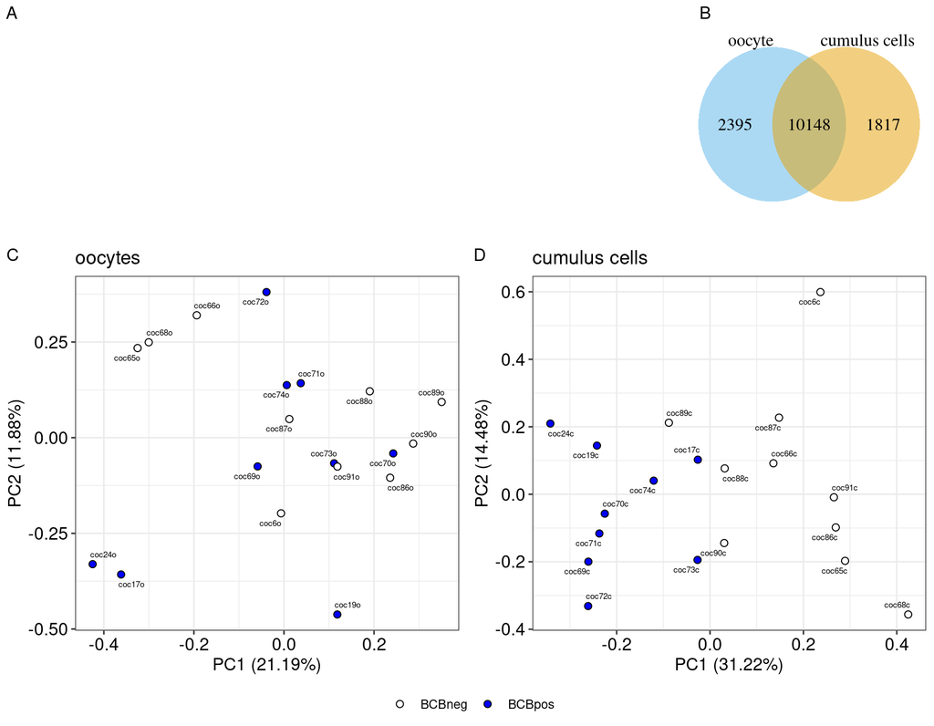

```r
 plot_grid(plot_grid(NULL,ggdraw(gene_numbers_venn_diagram),NULL, nrow=1,labels = c("A", "B"),label_size = 12, label_fontface = "plain", rel_widths=c(1.5,0.5,0.02)),
           plot_grid(plot_grid(pca_plot_oocyte,pca_plot_cumulus, labels = c("C", "D",""), label_fontface = "plain",label_size = 12), legend, nrow=2,rel_heights=c(1,0.1)), nrow=2, rel_heights=c(0.5,1))
```

#### Co-expression analysis between oocytes and surrounding cumulus cells

Calculate the co-expression for all 19 pairs of oocyte and cumulus cells.

```r
#oocyte_count_filtered
#cumulus_count_filtered

lib_size <- base::colSums(oocyte_count_filtered)
norm_factors <- calcNormFactors(object = oocyte_count_filtered, lib.size = lib_size, method = "TMM")
CTF_normalized_oocyte <- sweep(oocyte_count_filtered, 2, norm_factors, "/")
asinh_transf_CTF_normalized_oocyte<-asinh(CTF_normalized_oocyte)

lib_size <- base::colSums(cumulus_count_filtered)
norm_factors <- calcNormFactors(object = cumulus_count_filtered, lib.size = lib_size, method = "TMM")
CTF_normalized_cumulus <- sweep(cumulus_count_filtered, 2, norm_factors, "/")
asinh_transf_CTF_normalized_cumulus<-asinh(CTF_normalized_cumulus)
```

##### Supplemental figure 2

Obtain null distribution. For reproducibility the image used in the paper will be uploaded here.

```r
sample_a<-data.frame()
random_a<-data.frame()
random_b<-data.frame(matrix(NA, nrow = 150076995, ncol = 1))
for (i in (1:5)){

randomization<-sample(1:19,replace=F)

random_a<-WGCNA::cor(t(asinh_transf_CTF_normalized_oocyte[,randomization]),  t(asinh_transf_CTF_normalized_cumulus),  use = "pairwise.complete.obs", method="pearson")
random_a<-reshape2::melt(random_a)
random_b<-cbind(random_b,random_a$value)

sample_a<-rbind(sample_a,randomization)
}

random_b<-random_b[,-1]

summary(random_b)

plot_null_distribution<-ggplot()+
geom_histogram(aes(x=random_b[,1]), data=random_b, binwidth=0.01, alpha=0.2)+
geom_histogram(aes(x=random_b[,2]), data=random_b, binwidth=0.01, alpha=0.2)+
geom_histogram(aes(x=random_b[,3]), data=random_b, binwidth=0.01, alpha=0.2)+
geom_histogram(aes(x=random_b[,4]), data=random_b, binwidth=0.01, alpha=0.2)+
geom_histogram(aes(x=random_b[,5]), data=random_b, binwidth=0.01, alpha=0.2)+
scale_y_continuous(name="Count")+
scale_x_continuous(name="Correlation")+
theme(
panel.background = element_blank(),
panel.grid.major = element_blank(),
plot.background = element_blank(),
axis.line = element_line(color="black"),
axis.text = element_text(color="black", size=10),
axis.title.y=element_text(color="black", size=10,hjust=0),
axis.title.x = element_text(color="black", size=10)
)

pdf(file="/mnt/storage/lab_folder/shared_R_codes/fernando/BCB_oocyte_cumulus/results/Supplemental_fig_2022_03_23.pdf", width=4, height=4, bg="transparent" , onefile=TRUE)
plot_null_distribution
dev.off()
```

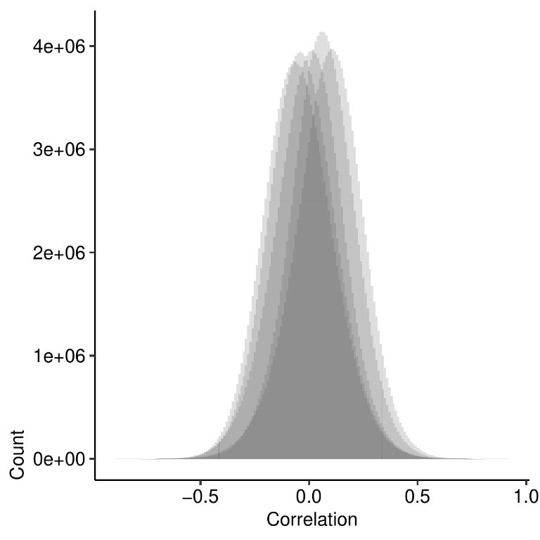

```r
ggdraw() + draw_image(magick::image_read_pdf("/mnt/storage/lab_folder/shared_R_codes/fernando/BCB_oocyte_cumulus/results/Supplemental_fig_2022_03_23.pdf", density = 300))
```

Estimate the values for empirical false discovery rate.

```r
setwd("/mnt/storage/lab_folder/shared_R_codes/fernando/BCB_oocyte_cumulus/results/")
asinh_transf_CTF_normalized_oocyte_big_matrix<- as.big.matrix(t(asinh_transf_CTF_normalized_oocyte) , type = "double",
                    separated = FALSE,
                    backingfile = "asinh_transf_CTF_normalized_oocyte.bin",
                    descriptorfile = "asinh_transf_CTF_normalized_oocyte.desc",
                    share=TRUE)
# get a description of the matrix
mdesc_oocyte <- describe(asinh_transf_CTF_normalized_oocyte_big_matrix)

asinh_transf_CTF_normalized_cumulus_big_matrix <- as.big.matrix(t(asinh_transf_CTF_normalized_cumulus), type = "double",
                      separated = FALSE,
                      backingfile = "asinh_transf_CTF_normalized_cumulus.bin",
                      descriptorfile = "asinh_transf_CTF_normalized_cumulus.desc",
                      share=TRUE)
# get a description of the matrix
mdesc_cumulus<- describe(asinh_transf_CTF_normalized_cumulus_big_matrix)

rand<-20000

sequence.correlation<-seq(0.80, 0.92, 0.01)

results <- filebacked.big.matrix(13,rand, type="double", init=0, separated=FALSE,
                                 backingfile="incidence_matrix.bin",
                                 descriptor="incidence_matrix.desc")
mdesc_result<- describe(results)

cl <- makeCluster(34)
registerDoParallel(cl)

results[,]<- foreach(i = 1:rand, .combine='cbind', .inorder=FALSE,.packages=c("WGCNA","bigmemory"), .noexport=c("asinh_transf_CTF_normalized_oocyte_big_matrix", "asinh_transf_CTF_normalized_cumulus_big_matrix"), .verbose=FALSE ) %dopar% {

    require(bigmemory)

    oocyte<- attach.big.matrix("asinh_transf_CTF_normalized_oocyte.desc")
    cumulus<- attach.big.matrix("asinh_transf_CTF_normalized_cumulus.desc")
    random<-WGCNA::cor(oocyte[sample(1:19,replace=FALSE),],  cumulus[,],  use = "pairwise.complete.obs", method="pearson")

    matrix( c(length(which(abs(random) > 0.80)) ,
    length(which(abs(random) > 0.81)),
    length(which(abs(random) > 0.82)),
    length(which(abs(random) > 0.83)),
    length(which(abs(random) > 0.84)),
    length(which(abs(random) > 0.85)),
    length(which(abs(random) > 0.86)),
    length(which(abs(random) > 0.87)),
    length(which(abs(random) > 0.88)),
    length(which(abs(random) > 0.89)),
    length(which(abs(random) > 0.90)),
    length(which(abs(random) > 0.91)),
    length(which(abs(random) > 0.92))), nrow = 13, ncol = 1, byrow = TRUE)

  }

stopCluster(cl)

total.rand <- 20000 * 150076995

qvalue_oocyte_cc<-data.frame(correlation = sequence.correlation, e.pvalue= (rowSums(results[,])+1)/(total.rand+1))

write.table(qvalue_oocyte_cc, file = "qvalue_oocyte_cc_2022_02_01.txt",quote = TRUE, sep = "\t",row.names = TRUE,col.names = TRUE)

system("rm asinh_transf_CTF_normalized_oocyte_pos.bin")
system("rm asinh_transf_CTF_normalized_oocyte_pos.desc")
system("rm asinh_transf_CTF_normalized_cumulus_pos.bin")
system("rm asinh_transf_CTF_normalized_cumulus_pos.desc")
system("rm incidence_matrix.bin")
system("rm incidence_matrix.desc")
```

```r
read.delim("/mnt/storage/lab_folder/shared_R_codes/fernando/BCB_oocyte_cumulus/results/qvalue_oocyte_cc_2022_02_01.txt", header=TRUE, sep= "\t",row.names=1, stringsAsFactors = FALSE)
```

```
##    correlation     e.pvalue
## 1         0.80 5.012540e-05
## 2         0.81 3.493701e-05
## 3         0.82 2.392004e-05
## 4         0.83 1.605620e-05
## 5         0.84 1.053819e-05
## 6         0.85 6.744419e-06
## 7         0.86 4.190283e-06
## 8         0.87 2.517387e-06
## 9         0.88 1.452871e-06
## 10        0.89 7.984028e-07
## 11        0.90 4.129484e-07
## 12        0.91 1.988023e-07
## 13        0.92 8.680011e-08
```

##### Supplemental table 3

```r
#colnames(asinh_transf_CTF_normalized_oocyte)
#colnames(asinh_transf_CTF_normalized_cumulus)

cor_oocyte_cc<-corAndPvalue(t(asinh_transf_CTF_normalized_oocyte),t(asinh_transf_CTF_normalized_cumulus), use = "pairwise.complete.obs",alternative="two.sided")

cor_oocyte_cc_value<-reshape2::melt(cor_oocyte_cc$cor)
cor_oocyte_cc_value<-as.data.table(cor_oocyte_cc_value)
cor_oocyte_cc_p_value<-reshape2::melt(cor_oocyte_cc$p)
cor_oocyte_cc_p_value<-as.data.table(cor_oocyte_cc_p_value)
cor_oocyte_cc<-cbind(cor_oocyte_cc_value,cor_oocyte_cc_p_value)
rm(cor_oocyte_cc_p_value,cor_oocyte_cc_value)
cor_oocyte_cc<-cor_oocyte_cc[,c(1,2,3,6)]
colnames(cor_oocyte_cc)<-c("gene_oocyte","gene_cumulus","correlation","p_value")
#head(cor_oocyte_cc)
cor_oocyte_cc<-setDT(cor_oocyte_cc[order(cor_oocyte_cc$p_value),])

#cor_oocyte_cc[abs(cor_oocyte_cc$correlation)>0.9]
#dim(cor_oocyte_cc[abs(cor_oocyte_cc$correlation)>0.85])
cor_oocyte_cc085<-cor_oocyte_cc[abs(cor_oocyte_cc$correlation)>0.85]
cor_oocyte_cc085_annotated<-setDT(cor_oocyte_cc085)
cor_oocyte_cc085_annotated$oocyte_gene_symbol <- annotation.ensembl.symbol$external_gene_name[match(cor_oocyte_cc085_annotated$gene_oocyte,annotation.ensembl.symbol$ensembl_gene_id)]
cor_oocyte_cc085_annotated$cumulus_gene_symbol <- annotation.ensembl.symbol$external_gene_name[match(cor_oocyte_cc085_annotated$gene_cumulus,annotation.ensembl.symbol$ensembl_gene_id)]

#write.table(cor_oocyte_cc085_annotated, file = "cor_oocyte_cc085_annotated_2022_02_02.txt",quote = TRUE, sep = "\t",row.names = TRUE,col.names = TRUE)
```

Plot the histogram for all values of coefficient.

```r
plot_histogram<-ggplot()+
geom_histogram(aes(x=correlation), data=cor_oocyte_cc, binwidth=0.01)+
scale_y_continuous(name="Count")+
scale_x_continuous(name="Correlation")+
theme(
panel.background = element_blank(),
panel.grid.major = element_blank(),
plot.background = element_blank(),
axis.line = element_line(color="black"),
axis.text = element_text(color="black", size=10),
axis.title.y=element_text(color="black", size=10,hjust=0),
axis.title.x = element_text(color="black", size=10)
)
```

Obtain gene connectivity.

```r
gene_connectivity<- cor_oocyte_cc085_annotated %>% dplyr::count(oocyte_gene_symbol) %>% dplyr::arrange(desc(n))
gene_connectivity<-gene_connectivity[gene_connectivity$n > 4,]
gene_connectivity<-gene_connectivity[!(gene_connectivity$oocyte_gene_symbol ==""),]
gene_connectivity$oocyte_gene_symbol<-factor(gene_connectivity$oocyte_gene_symbol, levels=c(gene_connectivity$oocyte_gene_symbol))


gene_connectivity_oocyte<-ggplot()+
geom_col( aes(x=oocyte_gene_symbol, y=n), data=gene_connectivity)+
 scale_x_discrete(name=NULL)+
  scale_y_continuous(name="Frequency")+
  #scale_y_break(c(100, 600 ) )+
  annotate("text",x=9, y=400, label="Oocytes")+
  theme_classic()+
  theme(
    axis.text.x = element_text(angle=90, face="italic", size=7, vjust=0.5,hjust = 0),
    axis.text.y = element_text(color="black", size=10),
    axis.title.y=element_text(color="black", size=10,hjust=0),
    axis.title.x=element_blank()
  )

gene_connectivity<- cor_oocyte_cc085_annotated %>% dplyr::count(cumulus_gene_symbol) %>% dplyr::arrange(desc(n))
gene_connectivity<-gene_connectivity[gene_connectivity$n > 4,]
gene_connectivity<-gene_connectivity[!(gene_connectivity$cumulus_gene_symbol ==""),]
gene_connectivity$cumulus_gene_symbol<-factor(gene_connectivity$cumulus_gene_symbol, levels=c(gene_connectivity$cumulus_gene_symbol))


gene_connectivity_cumulus<-ggplot()+
geom_col( aes(x=cumulus_gene_symbol, y=n), data=gene_connectivity)+
 scale_x_discrete(name=NULL)+
  scale_y_continuous(name="Frequency")+
  annotate("text",x=9, y=20, label="Cumulus cells")+
  theme_classic()+
  theme(
    axis.text.x = element_text(angle=90, face="italic", size=7, vjust=0.5,hjust = 0),
    axis.text.y = element_text(color="black", size=10),
    axis.title.y=element_text(color="black", size=10,hjust=0),
    axis.title.x=element_blank()
  )
```

Plot examples of co-expressed genes beteen oocyte and cumulus cells.

```r
cor_oocyte_cc_filtered<-cor_oocyte_cc[abs(cor_oocyte_cc$correlation)>0.85,]
cor_oocyte_cc_filtered$oocyte_gene_symbol <- annotation.ensembl.symbol$external_gene_name[match(cor_oocyte_cc_filtered$gene_oocyte,annotation.ensembl.symbol$ensembl_gene_id)]
cor_oocyte_cc_filtered$cumulus_gene_symbol <- annotation.ensembl.symbol$external_gene_name[match(cor_oocyte_cc_filtered$gene_cumulus,annotation.ensembl.symbol$ensembl_gene_id)]

cor_oocyte_cc_filtered$angle<-NA
cor_oocyte_cc_filtered$r.squared<-NA
cor_oocyte_cc_filtered$rmse<-NA
cor_oocyte_cc_filtered$fstatistic<-NA

for (i in seq(dim(cor_oocyte_cc_filtered)[1]))
{
gene_oocyte<-as.character(cor_oocyte_cc_filtered$gene_oocyte)[i]
gene_cumulus<-as.character(cor_oocyte_cc_filtered$gene_cumulus)[i]

gene_symbol_oocyte<-as.character(cor_oocyte_cc_filtered$oocyte_gene_symbol)[i]
gene_symbol_cumulus<-as.character(cor_oocyte_cc_filtered$cumulus_gene_symbol)[i]

expression_oocyte<-data.frame(expression_oocyte=t(oocyte_tpm_filtred[rownames(oocyte_tpm_filtred)==gene_oocyte,])[,1])
expression_cumulus<-data.frame( expression_cumulus=t(cumulus_tpm_filtred[rownames(cumulus_tpm_filtred)==gene_cumulus,])[,1])

model_oocyte_cc<-lm(expression_oocyte$expression_oocyte ~ expression_cumulus$expression_cumulus)

cor_oocyte_cc_filtered$angle[i]<-unname(atan(coef(model_oocyte_cc)[2]) * (180 / pi))
cor_oocyte_cc_filtered$r.squared[i]<-summary(model_oocyte_cc)$adj.r.squared
cor_oocyte_cc_filtered$rmse[i]<-sqrt(mean(model_oocyte_cc$residuals^2))
cor_oocyte_cc_filtered$fstatistic[i]<-unname(summary(model_oocyte_cc)$fstatistic[1])
}

cor_oocyte_cc_filtered<-cor_oocyte_cc_filtered[cor_oocyte_cc_filtered$angle > 40 & cor_oocyte_cc_filtered$angle < 60,]
cor_oocyte_cc_filtered<-cor_oocyte_cc_filtered[order(cor_oocyte_cc_filtered$rmse , decreasing = FALSE),]
cor_oocyte_cc_filtered<-cor_oocyte_cc_filtered[cor_oocyte_cc_filtered$r.squared>0.3,]
cor_oocyte_cc_filtered<-cor_oocyte_cc_filtered[c(2:4,6:14),]

dataframegraph<-data.frame()

for (i in c(1:12)){

gene_oocyte<-as.character(cor_oocyte_cc_filtered$gene_oocyte)[i]
gene_cumulus<-as.character(cor_oocyte_cc_filtered$gene_cumulus)[i]

gene_symbol_oocyte<-as.character(cor_oocyte_cc_filtered$oocyte_gene_symbol)[i]
gene_symbol_cumulus<-as.character(cor_oocyte_cc_filtered$cumulus_gene_symbol)[i]

expression_oocyte<-data.frame(expression_oocyte=t(oocyte_tpm_filtred[rownames(oocyte_tpm_filtred)==gene_oocyte,])[,1])
expression_cumulus<-data.frame( expression_cumulus=t(cumulus_tpm_filtred[rownames(cumulus_tpm_filtred)==gene_cumulus,])[,1])

graph<-i

dataframegraph<-rbind(data.frame(gene_oocyte,gene_cumulus,gene_symbol_oocyte,gene_symbol_cumulus,expression_oocyte,expression_cumulus,graph),dataframegraph)

}

plots<-list()

for (i in c(1:12)){

plots[[i]]<- ggplot(dataframegraph[dataframegraph$graph==i,], aes(x=expression_oocyte, y= expression_cumulus ))+
geom_point()+
geom_smooth(method='lm', formula= y~x)+
scale_x_continuous(name=dataframegraph[dataframegraph$graph==i,]$gene_symbol_oocyte[1])+
scale_y_continuous(name=dataframegraph[dataframegraph$graph==i,]$gene_symbol_cumulus[1])+
theme_classic(base_size=12)+
theme(
axis.title=element_text(face="italic", size=10),
axis.text=element_text(size=10, color="black"),
)

}

y.grob <- textGrob("cumulus cells", gp=gpar(fontface="plain", col="black", fontsize=10), rot=90)
x.grob <- textGrob("oocyte", gp=gpar(fontface="plain", col="black", fontsize=10))

plot_regr<-plot_grid(  grid.arrange(arrangeGrob(plot_grid(plotlist=plots, nrow=3), left = y.grob, bottom = x.grob)))
```

Test cumulus genes (significantly co-expressed with oocytes) for enrichment of biological processes.

##### Supplemental table 4

```r
gene.length<-read.delim("/mnt/storage/lab_folder/shared_R_codes/fernando/BCB_oocyte_cumulus/resources/2021_12_31_gene.length.txt.bz2", header=TRUE, sep= "\t",row.names=1, stringsAsFactors = FALSE)

all_genes<-data.frame( gene=rownames(cumulus_count_filtered), stringsAsFactors=FALSE )
rownames(all_genes)<-all_genes$gene
N_expressed_genes<-length(all_genes$gene)

gene.length<-gene.length[gene.length$ensembl_gene_id %in% all_genes$gene,]

annotation.genelength.biomart_vector<-gene.length$transcript_length
names(annotation.genelength.biomart_vector)<-gene.length$ensembl_gene_id

annotation.GO.BP.biomart<-annotation.GO.biomart[annotation.GO.biomart$namespace_1003=="biological_process", c(1,3)]
annotation.GO.BP.biomart<-annotation.GO.BP.biomart[annotation.GO.BP.biomart$ensembl_gene_id %in% rownames(all_genes),]
annotation.GO.MF.biomart<-annotation.GO.biomart[annotation.GO.biomart$namespace_1003=="molecular_function", c(1,3)]
annotation.GO.MF.biomart<-annotation.GO.MF.biomart[annotation.GO.MF.biomart$ensembl_gene_id %in% rownames(all_genes),]
```

```r
test.genes<-data.frame(a=unique(cor_oocyte_cc[abs(cor_oocyte_cc$correlation)>0.85]$gene_cumulus), stringsAsFactors=FALSE)
all_genes_numeric<-as.integer(all_genes$gene %in%test.genes$a)
names(all_genes_numeric)<-all_genes$gene

N_sig_genes<-length(test.genes$a)

set.seed(88972)
pwf<-nullp(all_genes_numeric, bias.data=annotation.genelength.biomart_vector, plot.fit=FALSE )
GO_BP_Cats_cumulus_corr_oocyte<-goseq(pwf,gene2cat=annotation.GO.BP.biomart, method ="Sampling", repcnt = 5000, use_genes_without_cat=FALSE)
#GO_BP_Cats_cumulus_corr_oocyte<-goseq(pwf,gene2cat=annotation.GO.BP.biomart, method ="Wallenius", use_genes_without_cat=FALSE)
GO_BP_Cats_cumulus_corr_oocyte<-GO_BP_Cats_cumulus_corr_oocyte[GO_BP_Cats_cumulus_corr_oocyte$numDEInCat>3,]
GO_BP_Cats_cumulus_corr_oocyte$FWER<-p.adjust(GO_BP_Cats_cumulus_corr_oocyte$over_represented_pvalue, method ="holm")
GO_BP_Cats_cumulus_corr_oocyte<-GO_BP_Cats_cumulus_corr_oocyte[with(GO_BP_Cats_cumulus_corr_oocyte, order(FWER,over_represented_pvalue, -numDEInCat)), ]
#head(GO_BP_Cats_cumulus_corr_oocyte, n=20)

GO_BP_Cats_cumulus_corr_oocyte$fold_enrichment<-(GO_BP_Cats_cumulus_corr_oocyte$numDEInCat/N_sig_genes)/(GO_BP_Cats_cumulus_corr_oocyte$numInCat/N_expressed_genes)
annotation.GO.BP.biomart_testgenes<-annotation.GO.BP.biomart[annotation.GO.BP.biomart$ensembl_gene_id %in% test.genes$a, ]
GO_BP_Cats_cumulus_corr_oocyte<-merge(GO_BP_Cats_cumulus_corr_oocyte,annotation.GO.BP.biomart_testgenes, by.x="category", by.y="go_id", all.x=TRUE, all.y=FALSE)
GO_BP_Cats_cumulus_corr_oocyte<-merge(GO_BP_Cats_cumulus_corr_oocyte, annotation.ensembl.symbol, by.x="ensembl_gene_id", by.y="ensembl_gene_id", all=FALSE, all.x=TRUE, all.y=FALSE)
GO_BP_Cats_cumulus_corr_oocyte<-GO_BP_Cats_cumulus_corr_oocyte[with(GO_BP_Cats_cumulus_corr_oocyte, order(FWER,term)), ]
GO_BP_Cats_cumulus_corr_oocyte<-GO_BP_Cats_cumulus_corr_oocyte[GO_BP_Cats_cumulus_corr_oocyte$FWER <= 0.11,]
GO_BP_Cats_cumulus_corr_oocyte$term<-factor(GO_BP_Cats_cumulus_corr_oocyte$term, levels=c(rev(unique(GO_BP_Cats_cumulus_corr_oocyte$term))))
#write.table(GO_BP_Cats_cumulus_corr_oocyte, file= "/mnt/storage/lab_folder/shared_R_codes/fernando/BCB_oocyte_cumulus/results/2022_02_02_GO_BP_Cats_cumulus_corr_oocyte_at_fdr01.txt", append = FALSE, quote = FALSE, sep = "\t" ,row.names = FALSE)
```

##### Supplemental table 5

Test oocyte genes (significantly co-expressed with cumulus cells) for enrichment of biological processes.

```r
gene.length<-read.delim("/mnt/storage/lab_folder/shared_R_codes/fernando/BCB_oocyte_cumulus/resources/2021_12_31_gene.length.txt.bz2", header=TRUE, sep= "\t",row.names=1, stringsAsFactors = FALSE)

all_genes<-data.frame( gene=rownames(oocyte_count_filtered), stringsAsFactors=FALSE )
rownames(all_genes)<-all_genes$gene
N_expressed_genes<-length(all_genes$gene)

gene.length<-gene.length[gene.length$ensembl_gene_id %in% all_genes$gene,]

annotation.genelength.biomart_vector<-gene.length$transcript_length
names(annotation.genelength.biomart_vector)<-gene.length$ensembl_gene_id

annotation.GO.BP.biomart<-annotation.GO.biomart[annotation.GO.biomart$namespace_1003=="biological_process", c(1,3)]
annotation.GO.BP.biomart<-annotation.GO.BP.biomart[annotation.GO.BP.biomart$ensembl_gene_id %in% rownames(all_genes),]
annotation.GO.MF.biomart<-annotation.GO.biomart[annotation.GO.biomart$namespace_1003=="molecular_function", c(1,3)]
annotation.GO.MF.biomart<-annotation.GO.MF.biomart[annotation.GO.MF.biomart$ensembl_gene_id %in% rownames(all_genes),]
```

```r
test.genes<-data.frame(a=unique(cor_oocyte_cc[abs(cor_oocyte_cc$correlation)>0.85]$gene_oocyte), stringsAsFactors=FALSE)
all_genes_numeric<-as.integer(all_genes$gene %in%test.genes$a)
names(all_genes_numeric)<-all_genes$gene

N_sig_genes<-length(test.genes$a)

set.seed(87175)
pwf<-nullp(all_genes_numeric, bias.data=annotation.genelength.biomart_vector, plot.fit=FALSE )
GO_BP_Cats_oocyte_corr_cumulus<-goseq(pwf,gene2cat=annotation.GO.BP.biomart, method ="Sampling", repcnt = 5000, use_genes_without_cat=FALSE)
GO_BP_Cats_oocyte_corr_cumulus<-GO_BP_Cats_oocyte_corr_cumulus[GO_BP_Cats_oocyte_corr_cumulus$numDEInCat>3,]
GO_BP_Cats_oocyte_corr_cumulus$FWER<-p.adjust(GO_BP_Cats_oocyte_corr_cumulus$over_represented_pvalue, method ="holm")
GO_BP_Cats_oocyte_corr_cumulus<-GO_BP_Cats_oocyte_corr_cumulus[with(GO_BP_Cats_oocyte_corr_cumulus, order(FWER,over_represented_pvalue, -numDEInCat)), ]
#head(GO_BP_Cats_oocyte_corr_cumulus, n=20)

GO_BP_Cats_oocyte_corr_cumulus$fold_enrichment<-(GO_BP_Cats_oocyte_corr_cumulus$numDEInCat/N_sig_genes)/(GO_BP_Cats_oocyte_corr_cumulus$numInCat/N_expressed_genes)
annotation.GO.BP.biomart_testgenes<-annotation.GO.BP.biomart[annotation.GO.BP.biomart$ensembl_gene_id %in% test.genes$a, ]
GO_BP_Cats_oocyte_corr_cumulus<-merge(GO_BP_Cats_oocyte_corr_cumulus,annotation.GO.BP.biomart_testgenes, by.x="category", by.y="go_id", all.x=TRUE, all.y=FALSE)
GO_BP_Cats_oocyte_corr_cumulus<-merge(GO_BP_Cats_oocyte_corr_cumulus, annotation.ensembl.symbol, by.x="ensembl_gene_id", by.y="ensembl_gene_id", all=FALSE, all.x=TRUE, all.y=FALSE)
GO_BP_Cats_oocyte_corr_cumulus<-GO_BP_Cats_oocyte_corr_cumulus[GO_BP_Cats_oocyte_corr_cumulus$FWER<0.1,]
GO_BP_Cats_oocyte_corr_cumulus<-GO_BP_Cats_oocyte_corr_cumulus[with(GO_BP_Cats_oocyte_corr_cumulus, order(FWER,term)), ]
GO_BP_Cats_oocyte_corr_cumulus$term<-factor(GO_BP_Cats_oocyte_corr_cumulus$term, levels=c(rev(unique(GO_BP_Cats_oocyte_corr_cumulus$term))))
#write.table(GO_BP_Cats_oocyte_corr_cumulus, file= "/mnt/storage/lab_folder/shared_R_codes/fernando/BCB_oocyte_cumulus/results/2022_02_01_GO_BP_Cats_oocyte_corr_cumulus_at_fdr01.txt", append = FALSE, quote = FALSE, sep = "\t" ,row.names = FALSE)
```

```r
GO_oocyte_plot<-ggplot(data=GO_BP_Cats_oocyte_corr_cumulus, aes(x=term, y=-log10(FWER)))+
  geom_point(aes(color=fold_enrichment))+
  scale_y_continuous(name=bquote(-Log[10](FWER)), limits=c(1,2.5))+
  coord_flip()+
  scale_colour_gradient(name= "Fold enrichment",low = "#B8B8B8", high = "#080808", na.value = NA,limits = c(1, 16))+
  scale_x_discrete(name=NULL)+
  theme_classic() +
  ggtitle("Oocytes - Biological processes") +
  theme(
    legend.direction = "horizontal",
    legend.position = c(0.9,1),
    legend.key.size = unit(0.5, 'mm'),
    legend.text=element_text(size=5,margin = margin(t = 0, r = 0, b = 0, l = 0, unit = "cm")),
    legend.title=element_text(size=5),
    legend.background=element_blank(),
    axis.text.x = element_text(color="black", size=10),
    axis.text.y = element_text(color="black", size=8),
    axis.title.y = element_blank(),
    axis.title.x = element_text(vjust=1,margin = margin(t = 0, r = 0, b = 0, l = 0, unit = "cm"), size = 10),
    plot.margin=unit(c(1,5,0,0), units="mm"),
    plot.title = element_text(size=8)
  ) + guides(color=guide_legend(title.position="top",title.hjust =0.5))

GO_cumulus_plot<-ggplot(data=GO_BP_Cats_cumulus_corr_oocyte, aes(x=term, y=-log10(FWER)))+
  geom_point(aes(color=fold_enrichment))+
  scale_y_continuous(name=bquote(-Log[10](FWER)), limits=c(0,2))+
  coord_flip()+
  scale_colour_gradient(name= "Fold enrichment",low = "#B8B8B8", high = "#080808", na.value = NA,limits = c(1, 15))+
  scale_x_discrete(name=NULL)+
  ggtitle("Cumulus cells - Biological processes") +
  theme_classic() +
  theme(
    legend.direction = "horizontal",
    legend.position = c(0.9,0.96),
    legend.key.size = unit(0.5, 'mm'),
    legend.text=element_text(size=5,margin = margin(t = 0, r = 0, b = 0, l = 0, unit = "cm")),
    legend.title=element_text(size=5),
    legend.background=element_blank(),
    axis.text.x = element_text(color="black", size=10),
    axis.text.y = element_text(color="black", size=8),
    axis.title.y = element_blank(),
    axis.title.x = element_text(vjust=1,margin = margin(t = 0, r = 0, b = 0, l = 0, unit = "cm"), size = 10),
    plot.margin=unit(c(1,5,0,0), units="mm"),
    plot.title = element_text(size=8)
  ) + guides(color=guide_legend(title.position="top",title.hjust =0.5))
```